# vision-demystify

## CPSC558 Final Project

a first attempt at understanding how deep CNNs make decisions and a gentle discussion on how it differs from humans

Keen You  
keen.you@yale.edu

```python
import tensorflow as tf
import numpy as np
import matplotlib.pyplot as plt
```

### Datasets

In this section, the three datasets used in this investigation are introduced - MNIST, fashion MNIST, and cifar10.

Both MNIST and fashion MNIST are grayscale images, with fashion MNIST supposedly 'more difficult' than MNIST. cifar10 consists of colored images. These 3 datasets are chosen since they contain different objects (hand-written digits, and actual physical objects) in both black and white and colored. Hope the variety can provide different perspectives on what deep neural networks are learning for classification tasks.

**Dataset #1 MNIST**  
60,000 28x28 grayscale images of the 10 digits, with 10,000 test images.

```python
from tensorflow.keras.datasets import mnist
```

```python
(x1_train, y1_train), (x1_test, y1_test) = mnist.load_data()
y1_train, y1_test = y1_train.reshape((-1,1)), y1_test.reshape((-1,1))
digit_labels = ['0', '1', '2', '3', '4',
                '5', '6', '7', '8', '9']
(x1_train.shape, y1_train.shape), (x1_test.shape, y1_test.shape)
```

```
(((60000, 28, 28), (60000, 1)), ((10000, 28, 28), (10000, 1)))
```

**Dataset #2 Fashion MNIST**  
60,000 28x28 grayscale images of 10 fashion categories with 10,000 test images.

```python
from tensorflow.keras.datasets import fashion_mnist
```

```python
(x2_train, y2_train), (x2_test, y2_test) = fashion_mnist.load_data()
y2_train, y2_test = y2_train.reshape((-1,1)), y2_test.reshape((-1,1))
fashion_labels = ['T-shirt/top', 'Trouser', 'Pullover', 'Dress', 'Coat',
                  'Sandal', 'Shirt', 'Sneaker', 'Bag', 'Ankle boot']
(x2_train.shape, y2_train.shape), (x2_test.shape, y2_test.shape)
```

```
(((60000, 28, 28), (60000, 1)), ((10000, 28, 28), (10000, 1)))
```

**Dataset #3 cifar10**  
50,000 32x32 color images over 10 categories, with 10,000 test images.

```python
from tensorflow.keras.datasets import cifar10
```

```python
(x3_train, y3_train), (x3_test, y3_test) = cifar10.load_data()
cifar_labels = ['airplane', 'automobile', 'bird', 'cat', 'deer', 'dog'
               'frog', 'horse', 'ship', 'truck']
(x3_train.shape, y3_train.shape), (x3_test.shape, y3_test.shape)
```

```
(((50000, 32, 32, 3), (50000, 1)), ((10000, 32, 32, 3), (10000, 1)))
```

**Understading datasets**  
I will plot a few images from each class for each dataset.

```python
from collections import defaultdict
# retrieve 5 images from each class
def collect_class_examples(y_train, n_class=10, n_per_class=5):
    counts = [0] * n_class
    index = 0
    images = defaultdict(list)

    while sum(counts) != n_per_class * n_class:
        label = y_train[index][0]
        if counts[label] != n_per_class:
            counts[label] += 1
            # save index
            images[label].append(index)
        index += 1

    # output a dictionary of class and corresponding image indices
    return images

def plot_images_by_class(images, x_train):
    n_class = len(images.keys())

    fig, axs = plt.subplots(n_class, 5, figsize=(12,9),
                            subplot_kw={'xticks': [], 'yticks': []})

    for index, ax in enumerate(axs.flat):
        label = index // 5
        image_index = images[label].pop(0)
        image = x_train[image_index]
        ax.imshow(image, cmap='gray')

    plt.tight_layout()
    plt.show()
```

```python
images1 = collect_class_examples(y1_train)
images2 = collect_class_examples(y2_train)
images3 = collect_class_examples(y3_train)
```

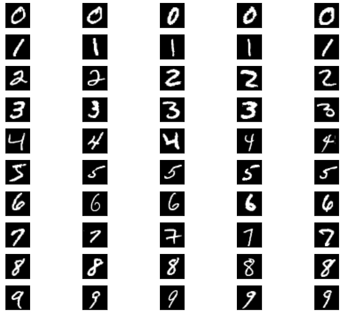

```python
plot_images_by_class(images1, x1_train)
```

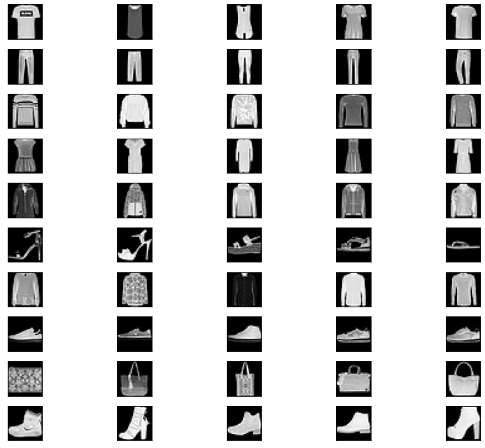

```python
plot_images_by_class(images2, x2_train)
```

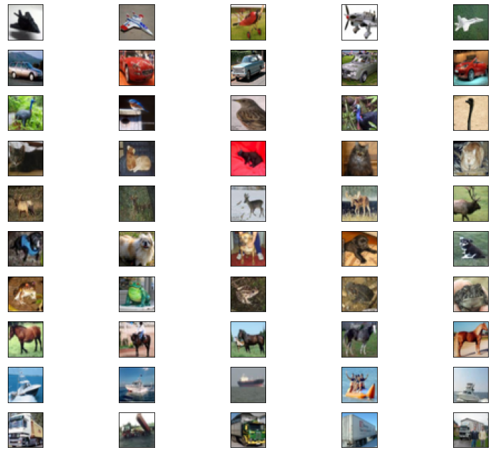

```python
plot_images_by_class(images3, x3_train)
```

**Pre-modeling discussion:**  
In MNIST, the digits are written using pixels of similar light intensities (white pixels), without much noise and located at center of the images. It is possible that filters in CNN learn to differentiate the different classes by the geometric structures of the digits (line segments, curves, etc).

In fashion MNIST, the objects are also located at center, and garments belonging to the same categories are presented from the same angle. The filters might rely on the shapes of the objects and maybe color gradients within the objects.

In cifar10, images of different objects are taken from different angles, without fixed background. Thus, it is possible for the filters to use any signals in classification.

Based on observing the images from these datasets, it is reasonable to consider the 3 datasets of increasing difficulty.

### Modeling

MNIST Digit

```python
def normalize(image):
    # normalize between [0, 1] [black, white]
    return (image - np.min(image)) * (1 / (np.max(image) - np.min(image)))
```

**logistic regression as basline**

```python
from sklearn.linear_model import LogisticRegression
from sklearn import preprocessing

# flatten 28x28 matrix to a feature vector
x1_train_feature = x1_train.reshape((-1, 28*28))
x1_train_feature = np.apply_along_axis(normalize, 1, x1_train_feature)

# scale
scaler = preprocessing.StandardScaler().fit(x1_train_feature)
x1_train_feature = scaler.transform(x1_train_feature)

clf1 = LogisticRegression(max_iter=1000).fit(x1_train_feature, y1_train.T[0])
```

```python
# preprocess test data
# flatten 28x28 matrix to a feature vector
x1_test_feature = x1_test.reshape((-1, 28*28))
x1_test_feature = np.apply_along_axis(normalize, 1, x1_test_feature)

# scale
scaler = preprocessing.StandardScaler().fit(x1_test_feature)
x1_test_feature = scaler.transform(x1_test_feature)
```

```python
train_accuracy = clf1.score(x1_train_feature, y1_train.T[0])
test_accuracy = clf1.score(x1_test_feature, y1_test.T[0])
print(f'Train accuracy: {train_accuracy}')
print(f'Test accuracy: {test_accuracy}')
```

```
Train accuracy: 0.9442
Test accuracy: 0.9208
```

Even with only flattened pixel vector, logistic regression is able to achieve 92% accuracy on test set.

```python
from tensorflow.python.keras.models import Sequential
from tensorflow.python.keras.layers import InputLayer, Input
from tensorflow.python.keras.layers import Reshape, MaxPooling2D
from tensorflow.python.keras.layers import Conv2D, Dense,Flatten,GlobalAveragePooling2D
```

**CNN for MNIST**

```python
model1 = Sequential()

model1.add(InputLayer(input_shape=(28,28,1)))
model1.add(Conv2D(filters=32, kernel_size=(3,3), strides=2, padding='same', activation='relu', name='layer_conv1'))
model1.add(MaxPooling2D(pool_size=(2,2), strides=2))
model1.add(Flatten())
# fully connected layer
model1.add(Dense(32,activation="relu",kernel_regularizer=tf.keras.regularizers.l2(l=0.0001)))
# output layer
model1.add(Dense(10,activation="softmax",kernel_regularizer=tf.keras.regularizers.l2(l=0.0001)))

# optimizer=tf.keras.optimizers.Adam(learning_rate=1e-3),
model1.compile(optimizer='adam',
  loss='categorical_crossentropy',
  metrics=['accuracy'])
```

```python
# data preprocessing
x1_train_feature = x1_train.astype('float32')/255.
x1_test_feature = x1_test.astype('float32')/255.

x1_train_feature = x1_train_feature.flatten().reshape(len(x1_train), 28, 28, 1)
y1_train_cat = tf.keras.utils.to_categorical(y1_train)
x1_test_feature = x1_test_feature.flatten().reshape(len(x1_test), 28, 28, 1)
y1_test_cat = tf.keras.utils.to_categorical(y1_test)
```

```python
results = model1.fit(x1_train_feature, y1_train_cat, epochs=10, batch_size=32, verbose=1)
```

```
2022-05-04 18:57:38.147504: I tensorflow/core/grappler/optimizers/custom_graph_optimizer_registry.cc:113] Plugin optimizer for device_type GPU is enabled.
```

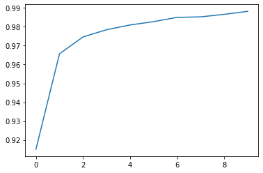

```python
plt.plot(results.history['accuracy'])
plt.show()
```

```python
# testing
result = model.evaluate(x1_test_feature, y1_test_cat, batch_size=32, verbose=1)
for name, value in zip(model.metrics_names, result):
    print(name, value)
```

```
loss 0.08779959380626678
accuracy 0.9792000651359558
```

**CNN for fashion MNIST**

```python
model2 = Sequential()

model2.add(InputLayer(input_shape=(28,28,1)))
model2.add(Conv2D(filters=32, kernel_size=(11,11), strides=1, padding='same', activation='relu', name='layer_conv1'))
model2.add(MaxPooling2D(pool_size=(2,2), strides=2))

# additional convoluational layer
model2.add(Conv2D(filters=64, kernel_size=(5,5), strides=2, padding='same', activation='relu', name='layer_conv2'))
model2.add(MaxPooling2D(pool_size=(2,2), strides=2))

# additional convoluational layer
model2.add(Conv2D(filters=128, kernel_size=(3,3), strides=2, padding='same', activation='relu', name='layer_conv3'))
model2.add(MaxPooling2D(pool_size=(2,2), strides=2))

model2.add(Flatten())
# fully connected layer
model2.add(Dense(32,activation="relu",kernel_regularizer=tf.keras.regularizers.l2(l=0.0001)))
# output layer
model2.add(Dense(10,activation="softmax",kernel_regularizer=tf.keras.regularizers.l2(l=0.0001)))

# optimizer=tf.keras.optimizers.Adam(learning_rate=1e-3),
model2.compile(optimizer='adam',
  loss='categorical_crossentropy',
  metrics=['accuracy'])
```

```python
# data preprocessing
x2_train_feature = x2_train.astype('float32')/255.
x2_test_feature = x2_test.astype('float32')/255.

x2_train_feature = x2_train_feature.flatten().reshape(len(x2_train), 28, 28, 1)
y2_train_cat = tf.keras.utils.to_categorical(y2_train)
x2_test_feature = x2_test_feature.flatten().reshape(len(x2_test), 28, 28, 1)
y2_test_cat = tf.keras.utils.to_categorical(y2_test)
```

```python
results = model2.fit(x2_train_feature, y2_train_cat, epochs=10, batch_size=32, verbose=1)
```

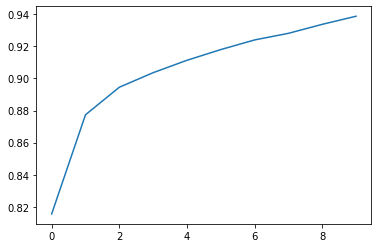

```python
plt.plot(results.history['accuracy'])
plt.show()
```

```python
# testing
result = model2.evaluate(x2_test_feature, y2_test_cat, batch_size=32, verbose=1)
for name, value in zip(model2.metrics_names, result):
    print(name, value)
```

```
2022-05-04 19:10:41.666551: I tensorflow/core/grappler/optimizers/custom_graph_optimizer_registry.cc:113] Plugin optimizer for device_type GPU is enabled.
```

```
loss 0.3197490870952606
accuracy 0.9013000130653381
```

Comparable model but with increasing kernel size as we go deeper into the net.

```python
model3 = Sequential()

model3.add(InputLayer(input_shape=(28,28,1)))
model3.add(Conv2D(filters=128, kernel_size=(3,3), strides=2, padding='same', activation='relu', name='layer_conv1'))
model3.add(MaxPooling2D(pool_size=(2,2), strides=2))

# additional convoluational layer
model3.add(Conv2D(filters=64, kernel_size=(5,5), strides=2, padding='same', activation='relu', name='layer_conv2'))
model3.add(MaxPooling2D(pool_size=(2,2), strides=2))

# additional convoluational layer
model3.add(Conv2D(filters=32, kernel_size=(11,11), strides=1, padding='same', activation='relu', name='layer_conv3'))
model3.add(MaxPooling2D(pool_size=(2,2), strides=2))

model3.add(Flatten())
# fully connected layer
model3.add(Dense(32,activation="relu",kernel_regularizer=tf.keras.regularizers.l2(l=0.0001)))
# output layer
model3.add(Dense(10,activation="softmax",kernel_regularizer=tf.keras.regularizers.l2(l=0.0001)))

# optimizer=tf.keras.optimizers.Adam(learning_rate=1e-3),
model3.compile(optimizer='adam',
  loss='categorical_crossentropy',
  metrics=['accuracy'])
```

```python
# training
results = model3.fit(x2_train_feature, y2_train_cat, epochs=10, batch_size=32, verbose=1)
```

```
2022-05-05 00:10:03.382716: I tensorflow/core/grappler/optimizers/custom_graph_optimizer_registry.cc:113] Plugin optimizer for device_type GPU is enabled.
```

```python
# testing
result = model3.evaluate(x2_test_feature, y2_test_cat, batch_size=32, verbose=1)
for name, value in zip(model3.metrics_names, result):
    print(name, value)
```

```
2022-05-05 00:13:38.324610: I tensorflow/core/grappler/optimizers/custom_graph_optimizer_registry.cc:113] Plugin optimizer for device_type GPU is enabled.
```

```
loss 0.2909684479236603
accuracy 0.9110000729560852
```

**CNN for cifar10**

```python
model4 = Sequential()

model4.add(InputLayer(input_shape=(32,32,3)))
model4.add(Conv2D(filters=32, kernel_size=(11,11), strides=2, padding='same', activation='relu', name='layer_conv1'))
model4.add(MaxPooling2D(pool_size=(2,2), strides=2))

# additional convoluational layer
model4.add(Conv2D(filters=64, kernel_size=(7,7), strides=2, padding='same', activation='relu', name='layer_conv2'))
model4.add(MaxPooling2D(pool_size=(2,2), strides=2))

# additional convoluational layer
model4.add(Conv2D(filters=128, kernel_size=(3,3), strides=1, padding='same', activation='relu', name='layer_conv3'))
model4.add(MaxPooling2D(pool_size=(2,2), strides=2))

model4.add(Flatten())
# fully connected layer
model4.add(Dense(32,activation="relu",kernel_regularizer=tf.keras.regularizers.l2(l=0.0001)))
# output layer
model4.add(Dense(10,activation="softmax",kernel_regularizer=tf.keras.regularizers.l2(l=0.0001)))

# optimizer=tf.keras.optimizers.Adam(learning_rate=1e-3),
model4.compile(optimizer='adam',
  loss='categorical_crossentropy',
  metrics=['accuracy'])
```

```python
# preprocessing
y3_train_cat = tf.keras.utils.to_categorical(y3_train)
y3_test_cat = tf.keras.utils.to_categorical(y3_test)

x3_train_feature = x3_train.astype('float32')/255.
x3_test_feature = x3_test.astype('float32')/255.
```

```python
# training
results = model4.fit(x3_train_feature, y3_train_cat, epochs=10, batch_size=32, verbose=1)
```

```
2022-05-05 00:13:46.517215: I tensorflow/core/grappler/optimizers/custom_graph_optimizer_registry.cc:113] Plugin optimizer for device_type GPU is enabled.
```

```python
# testing
result = model4.evaluate(x3_test_feature, y3_test_cat, batch_size=32, verbose=1)
for name, value in zip(model4.metrics_names, result):
    print(name, value)
```

```
2022-05-05 00:16:48.079128: I tensorflow/core/grappler/optimizers/custom_graph_optimizer_registry.cc:113] Plugin optimizer for device_type GPU is enabled.
```

```
loss 1.223360538482666
accuracy 0.6041000485420227
```

In the proposal, the plan is to compare mistake sets of simple linear classifiers and deep CNNs to interpret what deep NNs are learning. However, classifiers with similar discriminative powers do not necessary have the same inner workings. Thus, I have decided to study deep CNNs directly.

Since the goal here is to understand the inner workings, the models are not tuned to achieve best performances. However, I do have two different models with intentionally different configurations to see how the learned features differ with various kernel sizes at different depths.

**Model summaries:**

```python
model1.summary()
```

```
Model: "sequential_4"
_________________________________________________________________
Layer (type)                 Output Shape              Param #
=================================================================
layer_conv1 (Conv2D)         (None, 14, 14, 32)        320
_________________________________________________________________
max_pooling2d_4 (MaxPooling2 (None, 7, 7, 32)          0
_________________________________________________________________
flatten_4 (Flatten)          (None, 1568)              0
_________________________________________________________________
dense_8 (Dense)              (None, 32)                50208
_________________________________________________________________
dense_9 (Dense)              (None, 10)                330
=================================================================
Total params: 50,858
Trainable params: 50,858
Non-trainable params: 0
_________________________________________________________________
```

```python
model2.summary()
```

```
Model: "sequential_8"
_________________________________________________________________
Layer (type)                 Output Shape              Param #
=================================================================
layer_conv1 (Conv2D)         (None, 28, 28, 32)        3904
_________________________________________________________________
max_pooling2d_12 (MaxPooling (None, 14, 14, 32)        0
_________________________________________________________________
layer_conv2 (Conv2D)         (None, 7, 7, 64)          51264
_________________________________________________________________
max_pooling2d_13 (MaxPooling (None, 3, 3, 64)          0
_________________________________________________________________
layer_conv3 (Conv2D)         (None, 2, 2, 128)         73856
_________________________________________________________________
max_pooling2d_14 (MaxPooling (None, 1, 1, 128)         0
_________________________________________________________________
flatten_7 (Flatten)          (None, 128)               0
_________________________________________________________________
dense_14 (Dense)             (None, 32)                4128
_________________________________________________________________
dense_15 (Dense)             (None, 10)                330
=================================================================
Total params: 133,482
Trainable params: 133,482
Non-trainable params: 0
_________________________________________________________________
```

```python
model3.summary()
```

```
Model: "sequential_9"
_________________________________________________________________
Layer (type)                 Output Shape              Param #
=================================================================
layer_conv1 (Conv2D)         (None, 14, 14, 128)       1280
_________________________________________________________________
max_pooling2d_15 (MaxPooling (None, 7, 7, 128)         0
_________________________________________________________________
layer_conv2 (Conv2D)         (None, 4, 4, 64)          204864
_________________________________________________________________
max_pooling2d_16 (MaxPooling (None, 2, 2, 64)          0
_________________________________________________________________
layer_conv3 (Conv2D)         (None, 2, 2, 32)          247840
_________________________________________________________________
max_pooling2d_17 (MaxPooling (None, 1, 1, 32)          0
_________________________________________________________________
flatten_8 (Flatten)          (None, 32)                0
_________________________________________________________________
dense_16 (Dense)             (None, 32)                1056
_________________________________________________________________
dense_17 (Dense)             (None, 10)                330
=================================================================
Total params: 455,370
Trainable params: 455,370
Non-trainable params: 0
_________________________________________________________________
```

```python
model4.summary()
```

```
Model: "sequential_12"
_________________________________________________________________
Layer (type)                 Output Shape              Param #
=================================================================
layer_conv1 (Conv2D)         (None, 16, 16, 32)        11648
_________________________________________________________________
max_pooling2d_24 (MaxPooling (None, 8, 8, 32)          0
_________________________________________________________________
layer_conv2 (Conv2D)         (None, 4, 4, 64)          100416
_________________________________________________________________
max_pooling2d_25 (MaxPooling (None, 2, 2, 64)          0
_________________________________________________________________
layer_conv3 (Conv2D)         (None, 2, 2, 128)         73856
_________________________________________________________________
max_pooling2d_26 (MaxPooling (None, 1, 1, 128)         0
_________________________________________________________________
flatten_11 (Flatten)         (None, 128)               0
_________________________________________________________________
dense_22 (Dense)             (None, 32)                4128
_________________________________________________________________
dense_23 (Dense)             (None, 10)                330
=================================================================
Total params: 190,378
Trainable params: 190,378
Non-trainable params: 0
_________________________________________________________________
```

### Investigation

#### Understanding MNIST CNN

```python
model1.summary()
```

```
Model: "sequential_4"
_________________________________________________________________
Layer (type)                 Output Shape              Param #
=================================================================
layer_conv1 (Conv2D)         (None, 14, 14, 32)        320
_________________________________________________________________
max_pooling2d_4 (MaxPooling2 (None, 7, 7, 32)          0
_________________________________________________________________
flatten_4 (Flatten)          (None, 1568)              0
_________________________________________________________________
dense_8 (Dense)              (None, 32)                50208
_________________________________________________________________
dense_9 (Dense)              (None, 10)                330
=================================================================
Total params: 50,858
Trainable params: 50,858
Non-trainable params: 0
_________________________________________________________________
```

```python
conv1 = model1.layers[0]
conv1_weights, conv1_bias = conv1.get_weights()
conv1_weights.T.shape
```

```
(32, 1, 3, 3)
```

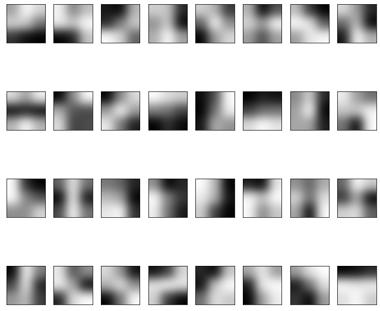

```python
fig, axs = plt.subplots(4, 8, figsize=(9,9),
                        subplot_kw={'xticks': [], 'yticks': []})

for index, ax in enumerate(axs.flat):
    ax.imshow(conv1_weights.T[index][0], cmap='gray', interpolation='gaussian')

plt.tight_layout()
plt.show()
```

We can see that each filter is vaguely learning some sub-image of the data. For example, 3rd filter on 1st row is learning a curve and the 1st filter on last row is learning a vertical line segment. However, with the fully-connected layer built on top, it is difficult to say how these feature are composed together to make the final prediction.

Next, we will look at the output of some filters on selected images.

```python
from tensorflow.python.keras import backend as K

output_conv1 = K.function(inputs=[conv1.input],
                          outputs=[conv1.output])
```

```python
# collect one image per class
digits = collect_class_examples(y1_test, n_class=10, n_per_class=1)
digits
```

```
defaultdict(list,
            {7: [0],
             2: [1],
             1: [2],
             0: [3],
             4: [4],
             9: [7],
             5: [8],
             6: [11],
             3: [18],
             8: [61]})
```

```python
def plot_activations(digit):
    image = x1_test_feature[digits[digit]]
    out1 = output_conv1([ image ])[0]

    fig, axs = plt.subplots(4, 8, figsize=(9,9),
                        subplot_kw={'xticks': [], 'yticks': []})

    for index, ax in enumerate(axs.flat):
        ax.imshow(out1[0,:,:,index], cmap='gray')

    plt.tight_layout()
    plt.show()
```

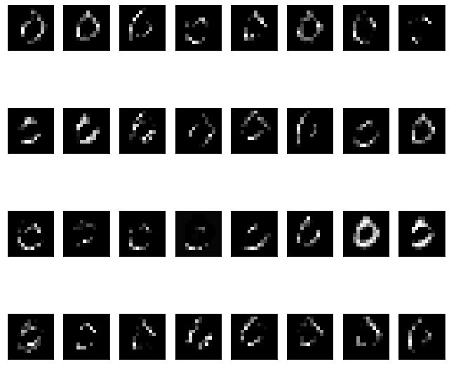

```python
plot_activations(0)
```

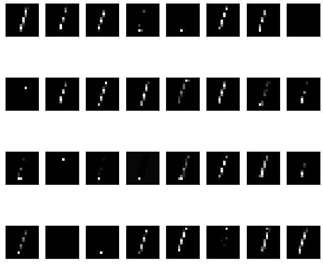

```python
plot_activations(1)
```

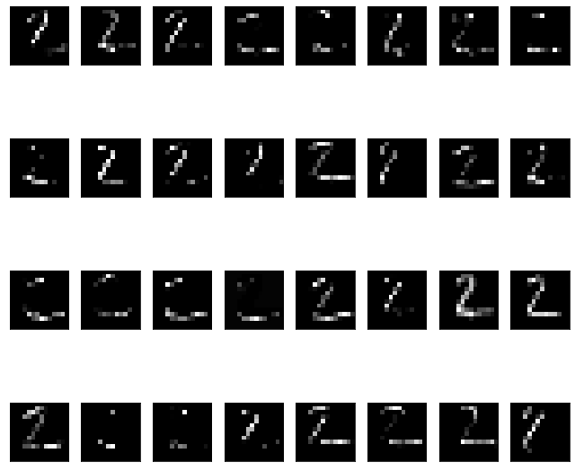

```python
plot_activations(2)
```

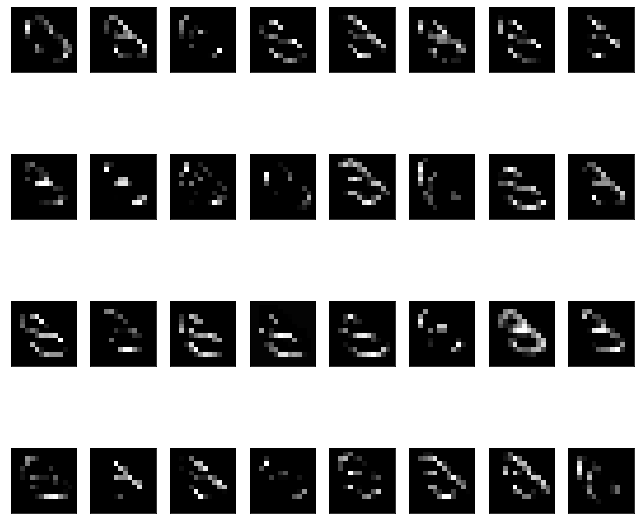

```python
plot_activations(3)
```

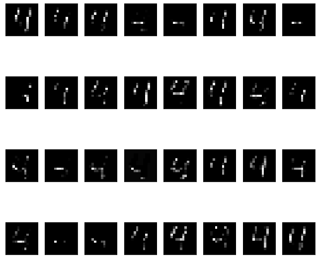

```python
plot_activations(4)
```

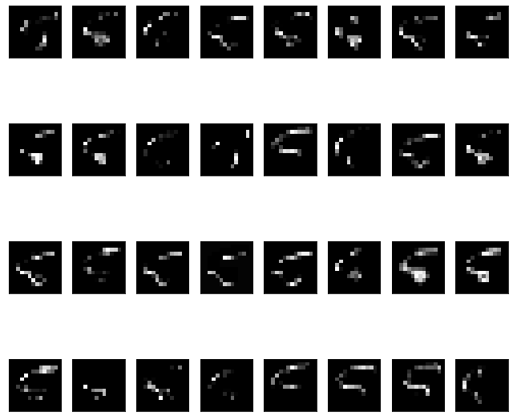

```python
plot_activations(5)
```

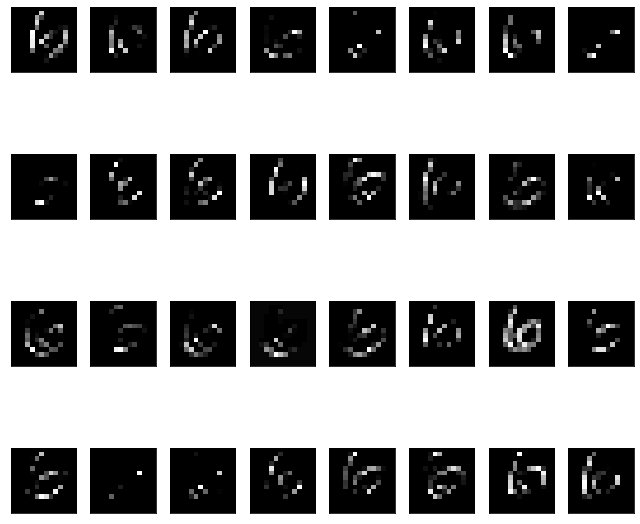

```python
plot_activations(6)
```

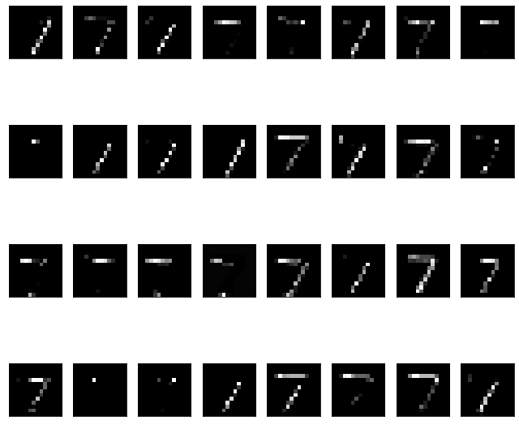

```python
plot_activations(7)
```

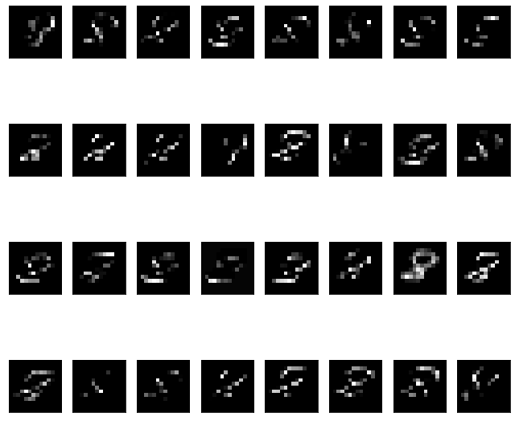

```python
plot_activations(8)
```

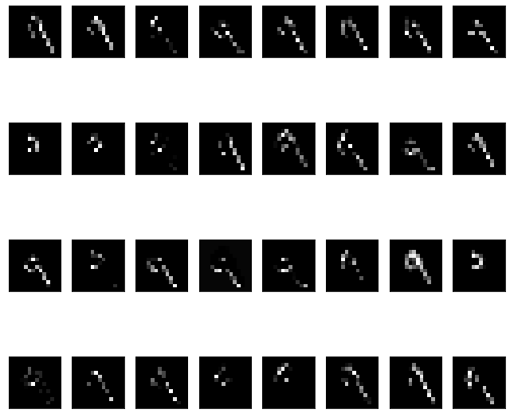

```python
plot_activations(9)
```

Directly observing filter activations shed some lights on what each filter gets from each image. However, comparing activations across classes does not tell much about what exactly the filters are learning.

There are multiple other common visualization techniques to understand what the filters are learning. However, I want to adopt a different approach in my investigation.

When making predictions, deep NNs rely on features composed from some portions of the original image. One way to test if a subimage contributes to the final decision is 'delete' the region and observe how the prediction changes. This is the main idea of the paper [Explanations for Attributing Deep Neural Network Predictions](https://doi.org/10.1007/978-3-030-28954-6_8), where a learning algorithm finds the minimal deletion mask such that the predictions are no longer correct.

Along similar lines, I want to explore a cruder form of this investigation by applying the deletion masks manually. This will provide some intuitive support of this approach (which the class has convinced me to be important).

```python
def add_noise(img, quadrant, noise_type='black'):
    image = np.copy(img)

    # compute coordiates based on quadrants
    height = len(image)
    midpt = height // 2
    if quadrant == 1:
        rows, cols = (0, midpt), (midpt, height)
    elif quadrant == 2:
        rows, cols = (0, midpt), (0, midpt)
    elif quadrant == 3:
        rows, cols = (midpt, height), (0, midpt)
    elif quadrant == 4:
        rows, cols = (midpt, height), (midpt, height)

    # apply noise
    for r in range(rows[0], rows[1]):
        for c in range(cols[0], cols[1]):
            if noise_type == 'black':
                image[r][c] = 0
            elif noise_type == 'gaussian':
                image[r][c] = np.random.normal(0.5, 0.1)
            elif noise_type == 'multi-channel-gaussian':
                image[r][c][0] = np.random.normal(0.5, 0.1)
                image[r][c][1] = np.random.normal(0.5, 0.1)
                image[r][c][2] = np.random.normal(0.5, 0.1)

    return image
```

**Perturbation on MNIST Examples**

Predict on original.

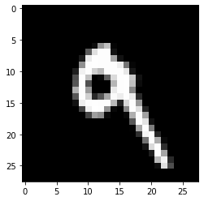

```
(array([[4.47587789e-09, 7.07123675e-08, 1.01686892e-05, 1.13227925e-05,
         1.62038741e-05, 1.75394234e-05, 9.24640919e-10, 5.72437706e-08,
         9.28208538e-05, 9.99851823e-01]], dtype=float32),
 9)
```

```python
img = x1_test_feature[7]
plt.imshow(img, cmap='gray')
plt.show()
img = img.flatten().reshape((28, 28, 1))
model1.predict(np.array([img])), np.argmax(model1.predict(np.array([img])))
```

Add noise to each quadrant.

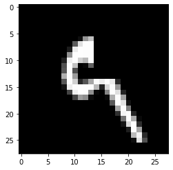

```
(array([[6.0027098e-08, 3.2750783e-08, 1.6074788e-04, 2.5850259e-05,
         1.0454358e-02, 1.9391850e-04, 9.4757770e-06, 5.1085291e-08,
         5.5488374e-04, 9.8860067e-01]], dtype=float32),
 9)
```

```python
img1 = add_noise(img, 1)
plt.imshow(img1, cmap='gray')
plt.show()
img1 = img1.flatten().reshape((28, 28, 1))
model1.predict(np.array([img1])), np.argmax(model1.predict(np.array([img1])))
```

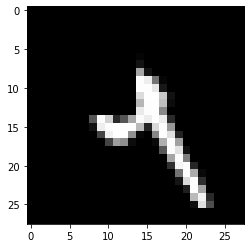

```
(array([[9.4801453e-07, 1.1632696e-02, 1.4694078e-01, 2.4412340e-03,
         9.7561896e-02, 1.3090973e-02, 2.7572971e-05, 6.3848885e-04,
         2.6456290e-03, 7.2501981e-01]], dtype=float32),
 9)
```

```python
img2 = add_noise(img, 2)
plt.imshow(img2, cmap='gray')
plt.show()
img2 = img2.flatten().reshape((28, 28, 1))
model1.predict(np.array([img2])), np.argmax(model1.predict(np.array([img2])))
```

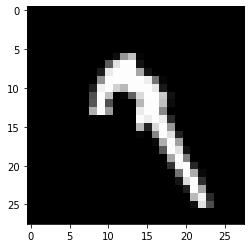

```
(array([[4.0243378e-07, 5.0494948e-04, 8.1495492e-04, 8.3674892e-04,
         1.3604908e-03, 1.0292850e-04, 3.9086377e-08, 7.4846792e-04,
         7.1203656e-04, 9.9491906e-01]], dtype=float32),
 9)
```

```python
img3 = add_noise(img, 3)
plt.imshow(img3, cmap='gray')
plt.show()
img3 = img3.flatten().reshape((28, 28, 1))
model1.predict(np.array([img3])), np.argmax(model1.predict(np.array([img3])))
```

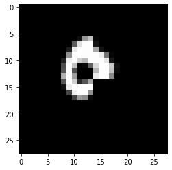

```
(array([[4.6606356e-06, 3.9110950e-09, 9.0657761e-07, 2.1477939e-05,
         1.3909637e-06, 1.4075795e-04, 2.7508079e-10, 8.4611386e-08,
         7.7467404e-05, 9.9975330e-01]], dtype=float32),
 9,
 array([9, 5, 8, 3, 0, 4, 2, 7, 1, 6]))
```

```python
img4 = add_noise(img, 4)
plt.imshow(img4, cmap='gray')
plt.show()
img4 = img4.flatten().reshape((28, 28, 1))
model1.predict(np.array([img4])), np.argmax(model1.predict(np.array([img4]))), np.argsort(model1.predict(np.array([img4])))[0][::-1]
```

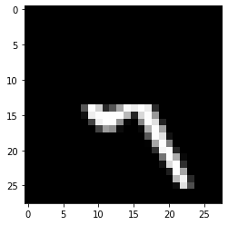

```
(array([[3.6343063e-06, 7.3708601e-05, 4.4197580e-01, 3.2406477e-03,
         3.7688810e-01, 1.1039965e-01, 3.3839226e-02, 8.2676408e-05,
         1.6563769e-03, 3.1840224e-02]], dtype=float32),
 2)
```

```python
# mask the entire upper half of image
img5 = add_noise(img, 1)
img5 = add_noise(img5, 2)

plt.imshow(img5, cmap='gray')
plt.show()
img5 = img5.flatten().reshape((28, 28, 1))
model1.predict(np.array([img5])), np.argmax(model1.predict(np.array([img5])))
```

When the entire upper half of the image is masked, the prediction becomes 2.

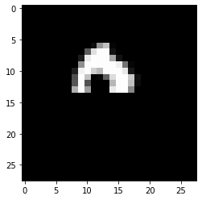

```
(array([[3.1589483e-05, 1.0108288e-05, 2.6014290e-04, 9.8631741e-04,
         2.7667361e-04, 2.4449693e-03, 1.9620481e-08, 4.2527795e-04,
         8.7518361e-04, 9.9468970e-01]], dtype=float32),
 9)
```

```python
# mask the entire lower half of image
img6 = add_noise(img, 3)
img6 = add_noise(img6, 4)

plt.imshow(img6, cmap='gray')
plt.show()
img6 = img6.flatten().reshape((28, 28, 1))
model1.predict(np.array([img6])), np.argmax(model1.predict(np.array([img6])))
```

When the entire lower half of the image is masked, the prediction is still correct.

**Discussion:**  
Very interesting observations.

It is possible that the prediction of the digit 9 relies heavily on multiple features from the filters, such that even if some of the features are deleted, the model is still able to make correct classifications based on remaining features.

This is great from a performance perspective, but it raises the concern that whether the filters are actually learning abstract geometry structures, or just idiosyncracies from this specific dataset.

Particularly, we see that when the 4th quadrant is deleted, the model prediction is still 9. However, to the human eyes, most people would say it is a 0. To the model however, 0 is only the 5th most likely prediction.

This example demonstrates that the CNN decision process differs from human perception. It reminds me of the geons, which are the basic units of objects and humans can recognize an object if the main geons making up the objects are visible.

In lines of geons, it could be interesting to identify and mask geons in images and observer how predictions change. This probably involves more intricate engineering design.

Now I will look at an example that is originally incorrectly classified.

```python
# find indices of wrongly classified examples
pred = model1.predict(x1_test_feature)
pred_labels = np.argmax(pred, axis=1)
incorrect_indices = np.array(pred_labels != y1_test.T[0]).nonzero()
incorrect_indices
```

```
(array([ 217,  247,  321,  340,  445,  449,  460,  495,  497,  543,  582,
         591,  625,  707,  716,  717,  726,  740,  839,  882,  883,  900,
         938,  939,  947,  956, 1014, 1039, 1112, 1181, 1182, 1226, 1232,
        1242, 1319, 1326, 1364, 1459, 1621, 1634, 1671, 1709, 1717, 1718,
        1737, 1790, 1800, 1865, 1878, 1901, 1955, 1982, 2001, 2035, 2043,
        2053, 2070, 2098, 2118, 2130, 2135, 2182, 2189, 2266, 2291, 2339,
        2363, 2369, 2387, 2395, 2447, 2454, 2488, 2514, 2526, 2597, 2654,
        2758, 2771, 2836, 2896, 2990, 2995, 3023, 3030, 3060, 3073, 3132,
        3206, 3218, 3289, 3405, 3422, 3503, 3520, 3550, 3558, 3559, 3567,
        3597, 3626, 3662, 3681, 3718, 3726, 3727, 3767, 3780, 3782, 3853,
        3871, 3902, 3906, 3941, 3951, 4063, 4075, 4078, 4176, 4201, 4205,
        4212, 4238, 4248, 4265, 4350, 4380, 4433, 4497, 4536, 4615, 4639,
        4690, 4740, 4761, 4783, 4807, 4814, 4838, 4956, 4978, 4997, 5068,
        5127, 5159, 5246, 5288, 5380, 5636, 5678, 5749, 5888, 5955, 6080,
        6091, 6161, 6532, 6555, 6560, 6572, 6574, 6576, 6578, 6597, 6603,
        6625, 6641, 6651, 7121, 7216, 7534, 7545, 7552, 7569, 7803, 7886,
        7971, 8071, 8097, 8217, 8273, 8287, 8408, 8520, 9015, 9280, 9540,
        9613, 9627, 9664, 9679, 9729, 9770, 9839]),)
```

An image of 6, but predicted as 5.

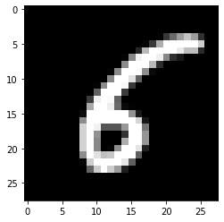

```
(array([[1.6081904e-04, 3.2812729e-08, 5.3834066e-07, 8.3143255e-05,
         1.3543408e-07, 8.1238645e-01, 1.8077795e-01, 1.1280222e-12,
         6.5901210e-03, 7.7357089e-07]], dtype=float32),
 5)
```

```python
img = x1_test_feature[217]
plt.imshow(img, cmap='gray')
plt.show()
img = img.flatten().reshape((28, 28, 1))
model1.predict(np.array([img])), np.argmax(model1.predict(np.array([img])))
```

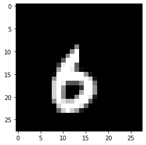

```
(array([[5.3310078e-03, 5.7755511e-07, 3.7915417e-04, 7.6820274e-05,
         7.4124955e-07, 4.4961665e-02, 9.4892597e-01, 7.5559156e-11,
         3.2384097e-04, 1.8317472e-07]], dtype=float32),
 6)
```

```python
img1 = add_noise(img, 1)
plt.imshow(img1, cmap='gray')
plt.show()
img1 = img1.flatten().reshape((28, 28, 1))
model1.predict(np.array([img1])), np.argmax(model1.predict(np.array([img1])))
```

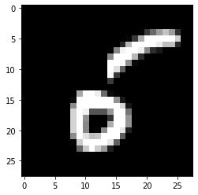

```
(array([[6.2151215e-05, 2.0489532e-08, 5.8730852e-06, 2.9453782e-05,
         2.1663071e-07, 9.2616093e-01, 5.2407473e-02, 7.8646034e-11,
         2.1333465e-02, 3.8114939e-07]], dtype=float32),
 5)
```

```python
img2 = add_noise(img, 2)
plt.imshow(img2, cmap='gray')
plt.show()
img2 = img2.flatten().reshape((28, 28, 1))
model1.predict(np.array([img2])), np.argmax(model1.predict(np.array([img2])))
```

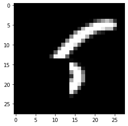

```
(array([[2.0830772e-07, 3.9990362e-05, 2.4150538e-07, 2.3938995e-04,
         6.0095056e-04, 9.9876213e-01, 4.2776188e-05, 1.2522432e-06,
         1.7495401e-04, 1.3811703e-04]], dtype=float32),
 5)
```

```python
img3 = add_noise(img, 3)
plt.imshow(img3, cmap='gray')
plt.show()
img3 = img3.flatten().reshape((28, 28, 1))
model1.predict(np.array([img3])), np.argmax(model1.predict(np.array([img3])))
```

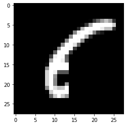

```
(array([[9.4219698e-03, 2.3168046e-05, 1.0392696e-06, 6.3000793e-05,
         9.4822853e-06, 9.6083516e-01, 1.2392209e-02, 6.5446376e-10,
         1.6661743e-02, 5.9223897e-04]], dtype=float32),
 5)
```

```python
img4 = add_noise(img, 4)
plt.imshow(img4, cmap='gray')
plt.show()
img4 = img4.flatten().reshape((28, 28, 1))
model1.predict(np.array([img4])), np.argmax(model1.predict(np.array([img4])))
```

Another very interesting observation.

The wrong prediction can be corrected by masking out first quadrant. While masks in other quadrants all result in a prediction of 5. A hypothesis is that the prediction 5 relies heavily on the the top curve. When it is eliminated by the first quadrant mask, the prediction becomes 6 and when it remains, the prediction is still 5.

This is evidence indicating the model is not learning the concept of a curve, but just the presence of white pixels resembling a curve at the specific positions of the images. This differs from human visual recognition tremendously. In both the original image and the one with first quadrant masked, humans will not change their recognition from 5 to 6 just because the upper curve is shorter. Instead, humans possibly utilizes the concept of a curve.

**Conclusion on MNIST**

I'm surprised even such crude form of feature occlusion reveals much about what CNN is not learning. An extension of this approach is to use more precise occlusion. For example, we could break digits down into 'geons' or composite shapes, and apply masks in that shape.

**Perturbation on fashion MNIST Examples**

```python
# get mistake sets
pred = model2.predict(x2_test_feature)
pred_labels = np.argmax(pred, axis=1)
incorrect_indices = np.array(pred_labels != y2_test.T[0]).nonzero()
incorrect_indices
```

```
2022-05-04 23:25:43.588841: I tensorflow/core/grappler/optimizers/custom_graph_optimizer_registry.cc:113] Plugin optimizer for device_type GPU is enabled.
```

```
(array([  12,   23,   25,   40,   42,   49,   51,   66,   67,   68,   74,
          89,   98,  107,  136,  147,  150,  153,  227,  239,  241,  244,
         247,  248,  252,  271,  283,  285,  286,  316,  322,  324,  325,
         361,  378,  381,  382,  396,  404,  413,  441,  444,  452,  454,
         455,  457,  460,  474,  476,  529,  531,  541,  548,  558,  563,
         565,  569,  570,  572,  578,  581,  607,  612,  634,  635,  639,
         669,  670,  685,  688,  711,  713,  724,  732,  737,  753,  760,
         787,  798,  851,  870,  881,  887,  890,  902,  905,  909,  921,
         956,  960,  965,  966,  971,  977,  979,  994, 1000, 1005, 1025,
        1043, 1046, 1053, 1056, 1064, 1101, 1111, 1129, 1131, 1139, 1142,
        1152, 1162, 1165, 1174, 1186, 1192, 1194, 1210, 1223, 1231, 1253,
        1254, 1280, 1294, 1300, 1315, 1329, 1335, 1336, 1339, 1352, 1353,
        1356, 1374, 1377, 1387, 1396, 1408, 1425, 1449, 1455, 1462, 1469,
        1471, 1487, 1504, 1509, 1522, 1528, 1533, 1543, 1559, 1596, 1620,
        1624, 1642, 1643, 1645, 1650, 1655, 1665, 1686, 1706, 1731, 1736,
```

[output cut: 75 more lines]

How is this Pullover??

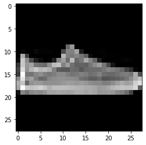

```
('Sneaker', 'Pullover')
```

```python
img = x2_test_feature[12]
plt.imshow(img, cmap='gray')
plt.show()
img = img.flatten().reshape((28, 28, 1))
fashion_labels[y2_test.T[0][12]], fashion_labels[np.argmax(model1.predict(np.array([img])))]
```

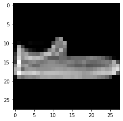

```
'Pullover'
```

```python
img1 = add_noise(img, 1)
plt.imshow(img1, cmap='gray')
plt.show()
img1 = img1.flatten().reshape((28, 28, 1))
fashion_labels[np.argmax(model1.predict(np.array([img1])))]
```

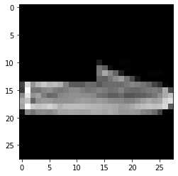

```
'Pullover'
```

```python
img2 = add_noise(img, 1)
img2 = add_noise(img, 2)
plt.imshow(img2, cmap='gray')
plt.show()
img2 = img2.flatten().reshape((28, 28, 1))
fashion_labels[np.argmax(model1.predict(np.array([img2])))]
```

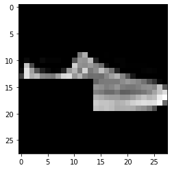

```
'Sneaker'
```

```python
img3 = add_noise(img, 3)
plt.imshow(img3, cmap='gray')
plt.show()
img3 = img3.flatten().reshape((28, 28, 1))
fashion_labels[np.argmax(model1.predict(np.array([img3])))]
```

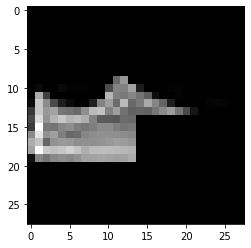

```
'Coat'
```

```python
img4 = add_noise(img, 4)
plt.imshow(img4, cmap='gray')
plt.show()
img3 = img4.flatten().reshape((28, 28, 1))
fashion_labels[np.argmax(model1.predict(np.array([img4])))]
```

The prediction for original, first quadrant mask, and second quadrant mask is pullover. When the third quadrant is masked, the prediction becomes sneaker. However, when the 4th quadrant is masked, the predictions becomes coat...

[figure not shown]

```python
# plots of pullover
pullovers = np.array(y2_test.T[0] == 2).nonzero()[0]
pullovers = np.random.choice(pullovers, 16)

fig, axs = plt.subplots(4, 4, figsize=(9,9),
                        subplot_kw={'xticks': [], 'yticks': []})

for index, ax in enumerate(axs.flat):
    ax.imshow(x2_test[pullovers[index]], cmap='gray', interpolation='gaussian')

plt.tight_layout()
plt.show()
```

Not entirely sure how to interpret this incorrect classification. It is likely that the model is utilizing some visual signals that are not obvious to the human eye.

Now let's try it on the other model.

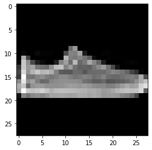

```
2022-05-05 00:17:03.567933: I tensorflow/core/grappler/optimizers/custom_graph_optimizer_registry.cc:113] Plugin optimizer for device_type GPU is enabled.
```

```
('Sneaker', 'Sneaker')
```

```python
img = x2_test_feature[12]
plt.imshow(img, cmap='gray')
plt.show()
img = img.flatten().reshape((28, 28, 1))
fashion_labels[y2_test.T[0][12]], fashion_labels[np.argmax(model3.predict(np.array([img])))]
```

It's correct.

**Perturbation on cifar10 Examples**

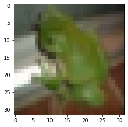

```
'bird'
```

```python
img = x3_test_feature[7]
plt.imshow(img, cmap='gray')
plt.show()
img = img.flatten().reshape((32, 32, 3))
cifar_labels[np.argmax(model4.predict(np.array([img])))]
```

[figure not shown]

```
'ship'
```

```python
img1 = add_noise(img, 1, 'multi-channel-gaussian')
plt.imshow(img1, cmap='gray')
plt.show()
img1 = img1.flatten().reshape((32, 32, 3))
cifar_labels[np.argmax(model4.predict(np.array([img1])))]
```

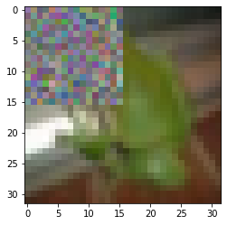

```
'bird'
```

```python
img2 = add_noise(img, 2, 'multi-channel-gaussian')
plt.imshow(img2, cmap='gray')
plt.show()
img1 = img1.flatten().reshape((32, 32, 3))
cifar_labels[np.argmax(model4.predict(np.array([img2])))]
```

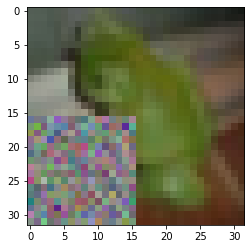

```
'horse'
```

```python
img3 = add_noise(img, 3, 'multi-channel-gaussian')
plt.imshow(img3, cmap='gray')
plt.show()
img3 = img3.flatten().reshape((32, 32, 3))
cifar_labels[np.argmax(model4.predict(np.array([img3])))]
```

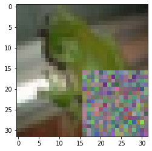

```
'bird'
```

```python
img4 = add_noise(img, 4, 'multi-channel-gaussian')
plt.imshow(img4, cmap='gray')
plt.show()
img4 = img4.flatten().reshape((32, 32, 3))
cifar_labels[np.argmax(model4.predict(np.array([img4])))]
```

We can see that applying Gaussian noise to colored images seem a lot more unnatural and differs significantly from training data. The paper discusses remedials for such artifacts.

### Conclusion

In this investigation, I use the idea of obfuscating features to understand what signals CNNs rely on in making prediction decisions. This simple exercise reveals that the CNN decision procedure possibly deviates quite significantly from humans'.

This ties back to some of my thoughts put in the paper. Explaining deep neural networks (DNN) in human-understandable concepts may inform the trajectory of DNN development. In other words, mimicking human cognition systems can be beneficial for AI systems. But is it possible that having DNNs break away from human cognitive processes can lead to other breakthroughs?

Either way, I think the development of deep neural network and the understanding of human cognitive systems are interwined. I would love to explore more of this relationship through other projects in future.